# Efeito dos conflitos no país Basco

Autor

Vitor Vasconcelos

Esse documento apresenta uma aplicação do método de Controle Sintético para avaliar o efeito causal dos conflitos no País Basco (entre os anos de 1960 e 1997). O objetivo é comparar o desempenho econômico do País Basco com um contrafactual sintético, construído a partir de outras regiões da Espanha que não sofreram os impactos dos conflitos.

A ideia de uma variavél de controle sintético é criar um contrafactual que represente o que teria acontecido com a unidade tratada (neste caso, o País Basco) na ausência do tratamento (os conflitos). O método utiliza uma combinação ponderada de unidades de controle para construir esse contrafactual. A ideia é que, ao comparar o desempenho do País Basco com o seu contrafactual sintético, podemos inferir o efeito dos conflitos sobre a economia da região.

O confractual é construído a partir de uma combinação ponderada de outras regiões da Espanha que não sofreram os mesmos impactos dos conflitos. A seguir, apresentamos a preparação dos dados, a aplicação do modelo e os resultados obtidos. Os pesos são definidos a partir de métodos númericos que minimizam a diferença entre o País Basco e o contrafactual sintético antes do início dos conflitos. A seguir, apresentamos a preparação dos dados, a aplicação do modelo e os resultados obtidos.

Essa aplicação é baseada no artigo “The Economic Costs of Conflict: Evidence from the Basque Country” de Alberto Abadie e Javier Gardeazabal (2003), publicado no American Economic Review. O artigo original pode ser acessado [aqui](https://www.aeaweb.org/articles?id=10.1257/000282803321455188).

# 1 Preparação dos Dados

```r
library(tidyverse)
library(ggplot2)
library(Synth)
library(knitr)

data(basque)

# Preparando os dados para o Controle Sintético
dados_preparados <- dataprep(
  foo = basque,

  predictors = c("school.illit", "school.prim", "school.med",
                 "school.high", "school.post.high", "invest"),
  predictors.op = "mean",
  time.predictors.prior = 1964:1969,

  special.predictors = list(
    list("gdpcap", 1960:1969, "mean"),
    list("sec.agriculture", 1961:1969, "mean"),
    list("sec.energy", 1961:1969, "mean"),
    list("sec.industry", 1961:1969, "mean"),
    list("sec.construction", 1961:1969, "mean"),
    list("sec.services.venta", 1961:1969, "mean"),
    list("sec.services.nonventa", 1961:1969, "mean"),
    list("popdens", 1969, "mean")
  ),

  dependent = "gdpcap", # variável dependente
  unit.variable = "regionno",
  unit.names.variable = "regionname",
  time.variable = "year",

  treatment.identifier = 17,
  controls.identifier = c(2:16, 18),

  time.optimize.ssr = 1960:1969,
  time.plot = 1955:1997
)
```

# 2 Aplicação do Modelo e Gráfico

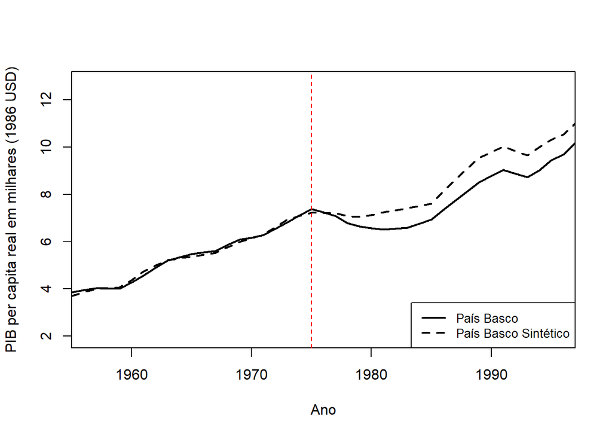

```r
# 1. Rodando o algoritmo de otimização capturando a saída para sumir com os logs do C
invisible(capture.output({
  resultado_synth <- synth(data.prep.obj = dados_preparados)
}))

# 2. Gerando o gráfico clássico da divergência
path.plot(synth.res = resultado_synth,
          dataprep.res = dados_preparados,
          Ylab = "PIB per capita real em milhares (1986 USD)",
          Xlab = "Ano",
          Legend = c("País Basco", "País Basco Sintético"),
          Legend.position = "bottomright")

# Adicionando uma linha vertical no ano em que o terrorismo escalou
abline(v = 1975, lty = 2, col = "red")
```

# 3 Matriz de Pesos e Resultados Numéricos

```r
# Extraindo as tabelas de resultados do pacote Synth
tabelas <- synth.tab(synth.res = resultado_synth,
                        dataprep.res = dados_preparados)

# Exibindo de forma limpa apenas as regiões que receberam peso positivo
pesos_regioes <- as.data.frame(tabelas$tab.w) %>%
  filter(w.weights > 0.001) %>%
  arrange(desc(w.weights)) %>%
  select(Cidade = unit.names, Pesos = w.weights)

knitr::kable(pesos_regioes, caption = "Regiões componentes do País Basco Sintético e seus respectivos pesos (W)")
```

Regiões componentes do País Basco Sintético e seus respectivos pesos (W)

|  | Cidade | Pesos |
| --- | --- | --- |
| 10 | Cataluna | 0.851 |
| 14 | Madrid (Comunidad De) | 0.149 |

# 4 Comparação Anual: País Basco Real vs. Contrafactual Sintético

```r
anos <- as.numeric(rownames(dados_preparados$Y1plot))
real <- as.vector(dados_preparados$Y1plot)

# Calculando a série sintética usando os pesos ótimos do modelo
pesos_w <- resultado_synth$solution.w
sintetico <- as.vector(dados_preparados$Y0plot %*% pesos_w)

tabela_comparacao <- data.frame(
  Ano = anos,
  Real = real,
  Sintetico = sintetico
) %>%
  mutate(
    Gap = Real - Sintetico,
    Gap_Percentual = (Gap / Sintetico) * 100
  )

# Filtrando para exibição a partir de 1970
tabela_exibicao <- tabela_comparacao %>%
  filter(Ano >= 1970)

# Renderizando a tabela formatada
kable(tabela_exibicao,
      digits = 2,
      col.names = c("Ano", "PIB Real (Basco)", "PIB Sintético", "Gap Absoluto", "Gap (%)"),
      caption = "Comparação Anual: País Basco Real vs. Contrafactual Sintético")
```

Comparação Anual: País Basco Real vs. Contrafactual Sintético

| Ano | PIB Real (Basco) | PIB Sintético | Gap Absoluto | Gap (%) |
| --- | --- | --- | --- | --- |
| 1970 | 6.17 | 6.14 | 0.03 | 0.52 |
| 1971 | 6.28 | 6.29 | -0.01 | -0.17 |
| 1972 | 6.56 | 6.62 | -0.07 | -0.99 |
| 1973 | 6.81 | 6.93 | -0.12 | -1.76 |
| 1974 | 7.11 | 7.09 | 0.02 | 0.26 |
| 1975 | 7.38 | 7.23 | 0.15 | 2.07 |
| 1976 | 7.23 | 7.22 | 0.01 | 0.17 |
| 1977 | 7.09 | 7.21 | -0.12 | -1.68 |
| 1978 | 6.79 | 7.07 | -0.29 | -4.07 |
| 1979 | 6.64 | 7.06 | -0.42 | -5.92 |
| 1980 | 6.56 | 7.13 | -0.57 | -7.95 |
| 1981 | 6.50 | 7.23 | -0.73 | -10.14 |
| 1982 | 6.55 | 7.33 | -0.78 | -10.65 |
| 1983 | 6.60 | 7.42 | -0.83 | -11.14 |
| 1984 | 6.76 | 7.52 | -0.75 | -10.04 |
| 1985 | 6.94 | 7.61 | -0.67 | -8.84 |
| 1986 | 7.33 | 8.12 | -0.79 | -9.68 |
| 1987 | 7.74 | 8.62 | -0.88 | -10.21 |
| 1988 | 8.12 | 9.09 | -0.97 | -10.63 |
| 1989 | 8.51 | 9.55 | -1.04 | -10.85 |
| 1990 | 8.78 | 9.79 | -1.01 | -10.33 |
| 1991 | 9.03 | 10.04 | -1.01 | -10.09 |
| 1992 | 8.87 | 9.84 | -0.96 | -9.80 |
| 1993 | 8.72 | 9.64 | -0.92 | -9.55 |
| 1994 | 9.02 | 9.99 | -0.97 | -9.71 |
| 1995 | 9.44 | 10.30 | -0.86 | -8.38 |
| 1996 | 9.69 | 10.54 | -0.85 | -8.08 |
| 1997 | 10.17 | 11.00 | -0.83 | -7.53 |

```r
# Calculando e imprimindo o ACE (Efeito Médio do Tratamento) pós-1975
ace_pos_1975 <- tabela_comparacao %>%
  filter(Ano >= 1975) %>%
  summarise(
    ACE_Absoluto = mean(Gap),
    ACE_Percentual = mean(Gap_Percentual)
  )

tabela_ace <- data.frame(
  Métrica = c("Queda Média Absoluta em milhares (1986 USD)", "Queda Média Relativa (%)"),
  Estimativa = c(ace_pos_1975$ACE_Absoluto, ace_pos_1975$ACE_Percentual)
)

kable(tabela_ace,
      digits = 2,
      col.names = c("Indicador de Impacto", "Valor Médio (1975-1997)"),
      caption = "Estimativa do Efeito Médio do Tratamento (ACE) no Período Pós-Conflito")
```

Estimativa do Efeito Médio do Tratamento (ACE) no Período Pós-Conflito

| Indicador de Impacto | Valor Médio (1975-1997) |
| --- | --- |
| Queda Média Absoluta em milhares (1986 USD) | -0.70 |
| Queda Média Relativa (%) | -7.96 |